# Automatic Monthly Attendance Data Extraction and Management Tool, TUTORIAL

## Prerequisites:

1. Before running the tool make sure that each individual participant has their own time sheet in their own respective folder.
2. Make sure that the file name that is in each folder is the same as well.

## Usage:

### Step 1: Install Dependencies

> To install the necessary Python libraries, run the following command by clicking on the play buton on the left:

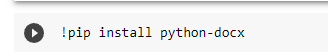

## Step 2: Mount Google Drive and Starting the Script

> Like how you ran the snippet from before in step one do the same for the next code snippet. The script needs access to Google Drive. Don't worry; it's easy to set up! Refer to the following images below to mount your Google Drive. This step ensures that the script can access and save files to your Google Drive account. Note: The image only shows a portion of the code!

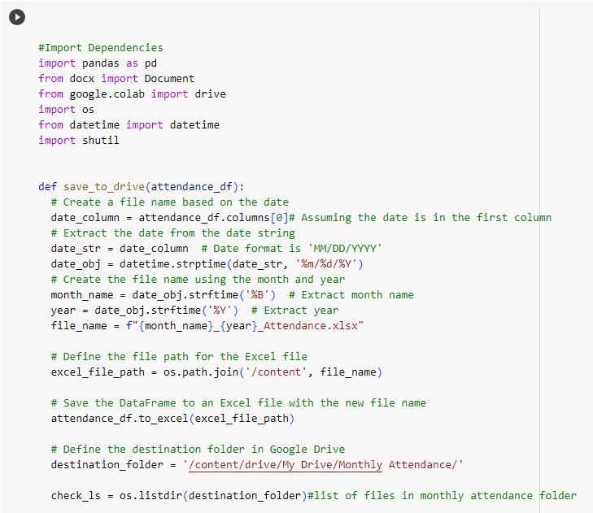

### 1. Running the script

[figure not shown]

### 2. Connect to Google Drive. It will open a new window asking for access.

[figure not shown]

### 3. Select the account associated.

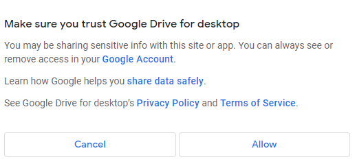

### 4. Give accesss so that the script can run properly and mount the Google Drive

## Step 3:Enter the File Name

> When prompted, type the name of the individual timesheet file, including the .docx extension (e.g., "9-2023 Participant Timesheet.docx"). If you're not sure, don't worry; it will remind you of the correct format.

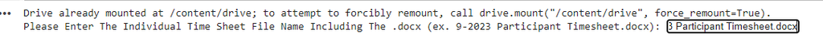

### After entering file name the program will ask a series of questions. Simply type your answer in the box and press enter.

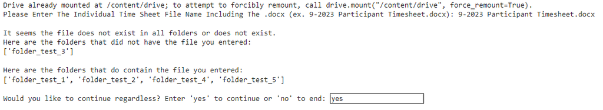

### Step 4: Finish

> After following the prompts the program will finish and you can check for the Monthly time sheet in the folder on your Google Drive.

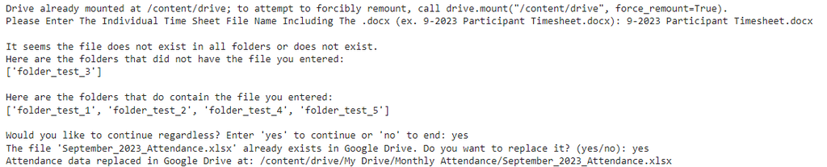

### Below you can see that it created an excel file with its own name based on the data extracted from the Docx files.

[figure not shown]

# Attendance Insights Extractor Script Tutorial

## Prerequisites

> Before using the script, make sure you have the following:
1. An Excel file containing attendance data.
2. The Excel File containing the attendance data should be generated from the script: Automatic Monthly Attendance Data Extraction and Management Tool or have the same format as the generated excel file.
3. Have access to Google Drive account

## Usage:

Step 1: Click on the run button (aka the play button)

Step 2: Enter the file name into the box

Step 3: Follow and enter information as the scripts asks.

### Refer to the images below:

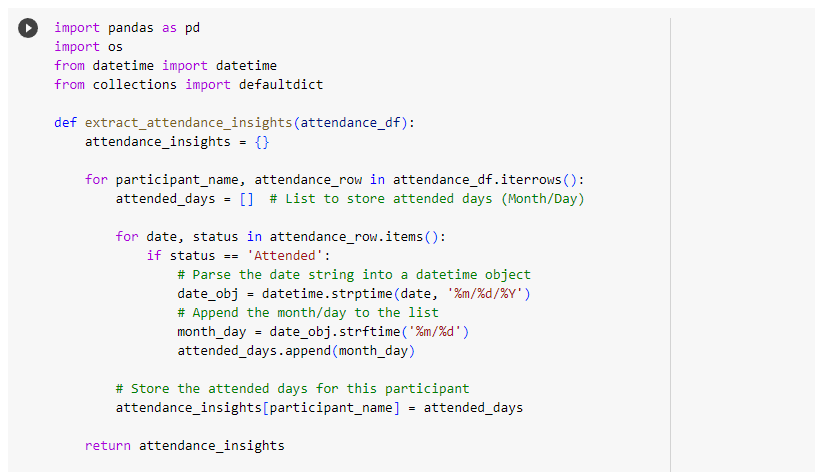

### ------------------------------------------------------------------------

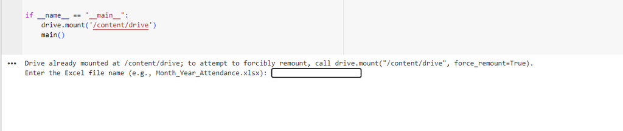

### ------------------------------------------------------------------------

### Enter the file name from the excel file in the Monthly Attendance folder

[figure not shown]

### ------------------------------------------------------------------------------

### RESULTS:

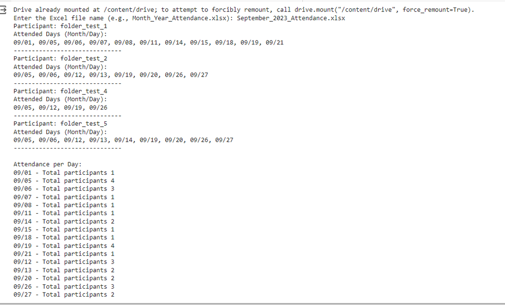